# Image_Thresholding_in_OpenCV

```python
import numpy as np
from sklearn.datasets import load_sample_image
from skimage import io
import cv2

# Visualisation libraries

## Text
from colorama import Fore, Back, Style
from IPython.display import Image, display, Markdown, Latex

## matplotlib
import matplotlib.pyplot as plt
from matplotlib.font_manager import FontProperties
from mpl_toolkits.axes_grid1.inset_locator import inset_axes
plt.style.use('seaborn-whitegrid')
import matplotlib as mpl
mpl.rcParams['figure.figsize'] = (17, 6)

%matplotlib inline

## seaborn
import seaborn as sns

import warnings
warnings.filterwarnings("ignore")
```

We use the sklearn [image dataset](https://scikit-learn.org/stable/modules/generated/sklearn.datasets.load_sample_images.html#sklearn.datasets.load_sample_images) to demonstrate basic operations using Open CV.

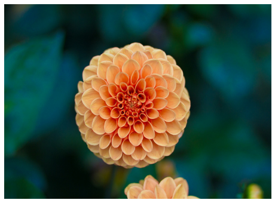

```python
Img = load_sample_image('flower.jpg')
fig, ax = plt.subplots(1, 1 , figsize = (8, 6))
font = FontProperties()
font.set_weight('bold')
_ = ax.imshow(Img)
_ = ax.axis('off')
_ = ax.set_aspect('auto')
```

# Simple Thresholding

Applies a fixed-level threshold to each array element. It can be done as follows,

`cv2.threshold(Source, threshold value, maximum value, type[, Output]) → retval, Output`

Parameters:

- **Source**: input array (single-channel, 8-bit or 32-bit floating point).
- **Output**: output array of the same size and type as Source.
- **threshold value**: threshold value.
- **maximum value** – maximum value to use with the THRESH_BINARY and THRESH_BINARY_INV thresholding types.
- type:
  - THRESH_BINARY
  - THRESH_BINARY_INV
  - THRESH_TRUNC
  - THRESH_TOZERO
  - THRESH_TOZERO_INV

## THRESH_BINARY

$$\text{Output }(x,y) = \begin{cases}\text{maximum value}&\mbox{if source(x,y) > threshold value},\\0,&\mbox{otherwise}\end{cases}$$

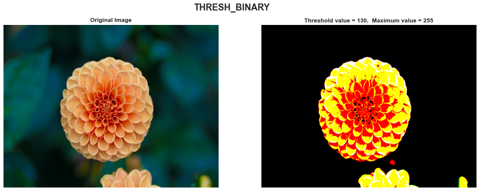

```python
_ , Out = cv2.threshold(Img, 130, 255,cv2.THRESH_BINARY)

fig, ax = plt.subplots(1, 2 , figsize = (17, 6))
ax = ax.ravel()
font = FontProperties()
font.set_weight('bold')
_ = fig.suptitle('THRESH_BINARY', fontproperties=font, fontsize = 18)

_ = ax[0].imshow(Img)
_ = ax[0].set_title('Original Image', fontproperties=font, fontsize = 12)
_ = ax[1].imshow(Out)
_ = ax[1].set_title('Threshold value = 130,  Maximum value = 255', fontproperties=font, fontsize = 12)
for i in range(2):
    _ = ax[i].set_aspect('auto')
    _ = ax[i].axis('off')
del i
```

## THRESH_BINARY_INV

$$\text{Output} (x,y) = \begin{cases}0&\mbox{if source(x,y) > threshold value},\\\text{maximum value},&\mbox{otherwise}\end{cases}$$

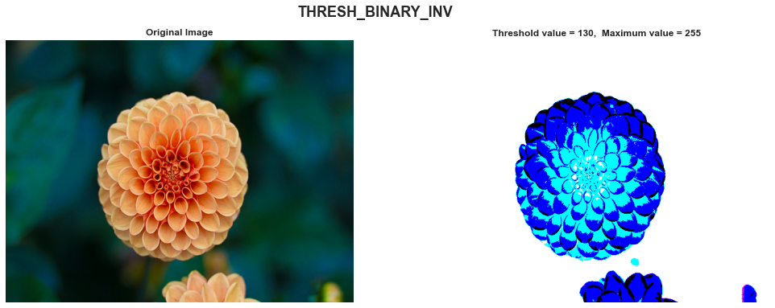

```python
_ , Out = cv2.threshold(Img, 130, 255,cv2.THRESH_BINARY_INV)

fig, ax = plt.subplots(1, 2 , figsize = (17, 6))
ax = ax.ravel()
font = FontProperties()
font.set_weight('bold')
_ = fig.suptitle('THRESH_BINARY_INV', fontproperties=font, fontsize = 18)

_ = ax[0].imshow(Img)
_ = ax[0].set_title('Original Image', fontproperties=font, fontsize = 12)
_ = ax[1].imshow(Out)
_ = ax[1].set_title('Threshold value = 130,  Maximum value = 255', fontproperties=font, fontsize = 12)
for i in range(2):
    _ = ax[i].set_aspect('auto')
    _ = ax[i].axis('off')
del i
```

## THRESH_TRUNC

$$\text{Output} (x,y) = \begin{cases}\text{threshhold}&\mbox{if source(x,y) > tthreshold value},\\\text{source(x,y)},&\mbox{otherwise}\end{cases}$$

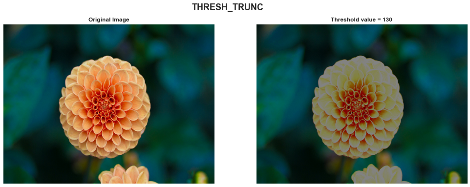

```python
_ , Out = cv2.threshold(Img, thresh = 130, maxval = 255, type = cv2.THRESH_TRUNC)

fig, ax = plt.subplots(1, 2 , figsize = (17, 6))
ax = ax.ravel()
font = FontProperties()
font.set_weight('bold')
_ = fig.suptitle('THRESH_TRUNC', fontproperties=font, fontsize = 18)

_ = ax[0].imshow(Img)
_ = ax[0].set_title('Original Image', fontproperties=font, fontsize = 12)
_ = ax[1].imshow(Out)
_ = ax[1].set_title('Threshold value = 130', fontproperties=font, fontsize = 12)
for i in range(2):
    _ = ax[i].set_aspect('auto')
    _ = ax[i].axis('off')
del i
```

## THRESH_TOZERO

$$\text{Output} (x,y) = \begin{cases}\text{source(x,y)}&\mbox{if source(x,y) > tthreshold value},\\0,&\mbox{otherwise}\end{cases}$$

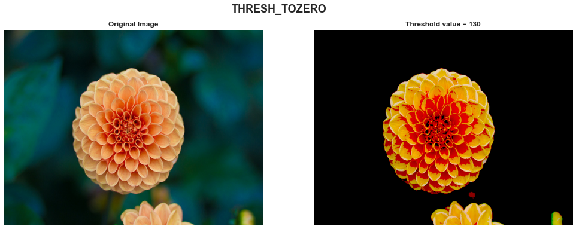

```python
_ , Out = cv2.threshold(Img, thresh = 130, maxval = 255, type = cv2.THRESH_TOZERO)

fig, ax = plt.subplots(1, 2 , figsize = (17, 6))
ax = ax.ravel()
font = FontProperties()
font.set_weight('bold')
_ = fig.suptitle('THRESH_TOZERO', fontproperties=font, fontsize = 18)

_ = ax[0].imshow(Img)
_ = ax[0].set_title('Original Image', fontproperties=font, fontsize = 12)
_ = ax[1].imshow(Out)
_ = ax[1].set_title('Threshold value = 130', fontproperties=font, fontsize = 12)
for i in range(2):
    _ = ax[i].set_aspect('auto')
    _ = ax[i].axis('off')
del i
```

## THRESH_TOZERO_INV

$$\text{Output} (x,y) = \begin{cases}0&\mbox{if source(x,y) > tthreshold value},\\\text{source(x,y)},&\mbox{otherwise}\end{cases}$$

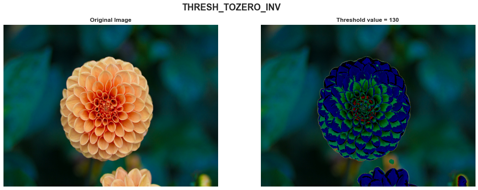

```python
_ , Out = cv2.threshold(Img, thresh = 130, maxval = 255, type = cv2.THRESH_TOZERO_INV)

fig, ax = plt.subplots(1, 2 , figsize = (17, 6))
ax = ax.ravel()
font = FontProperties()
font.set_weight('bold')
_ = fig.suptitle('THRESH_TOZERO_INV', fontproperties=font, fontsize = 18)

_ = ax[0].imshow(Img)
_ = ax[0].set_title('Original Image', fontproperties=font, fontsize = 12)
_ = ax[1].imshow(Out)
_ = ax[1].set_title('Threshold value = 130', fontproperties=font, fontsize = 12)
for i in range(2):
    _ = ax[i].set_aspect('auto')
    _ = ax[i].axis('off')
del i
```